# Outliers

## What is an outlier?

[figure not shown]

**Outlier** is a general term to describe a data point that doesn't follow the pattern set by the bulk of the data, when one takes into account the model.

## Outlier Example One

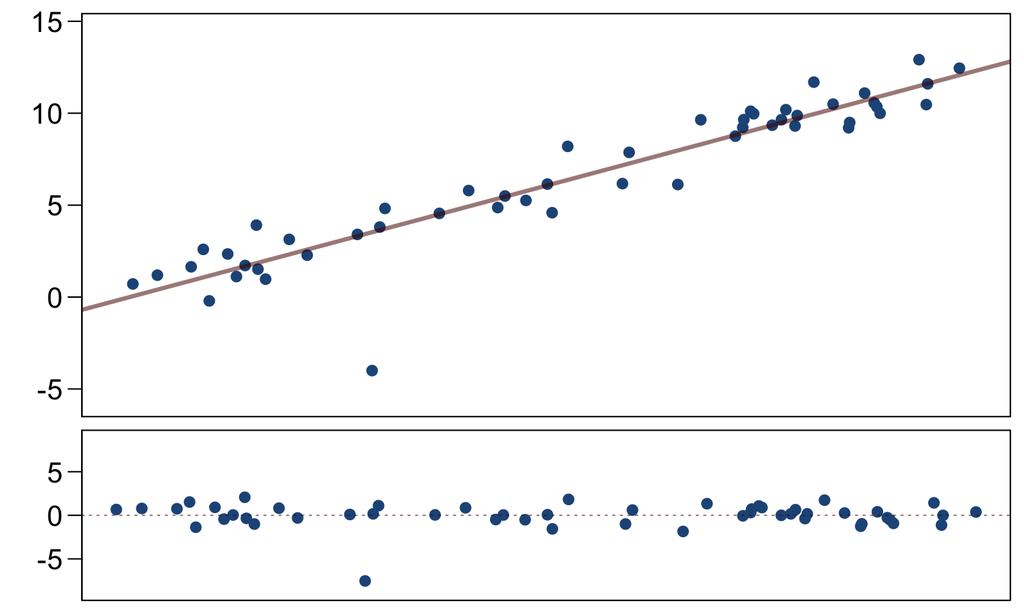

## Outlier Example Two

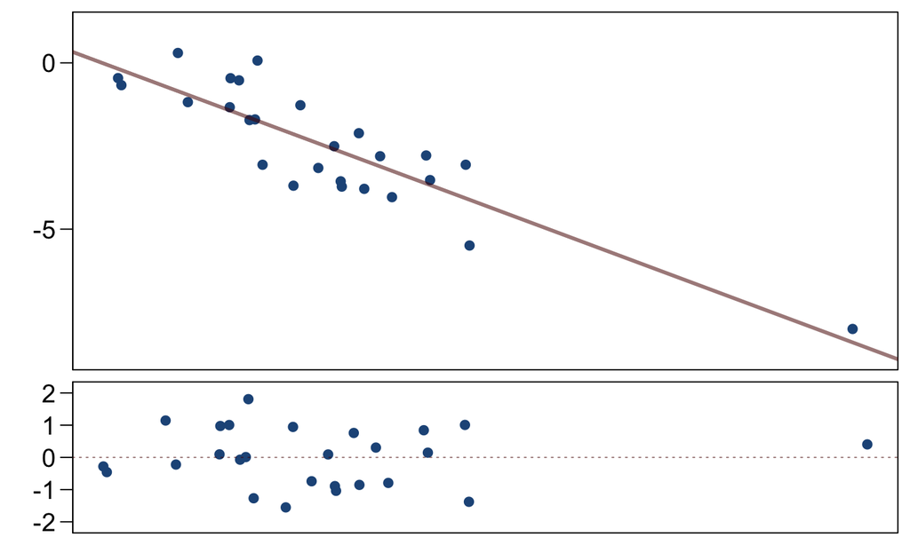

## Outlier Example Three

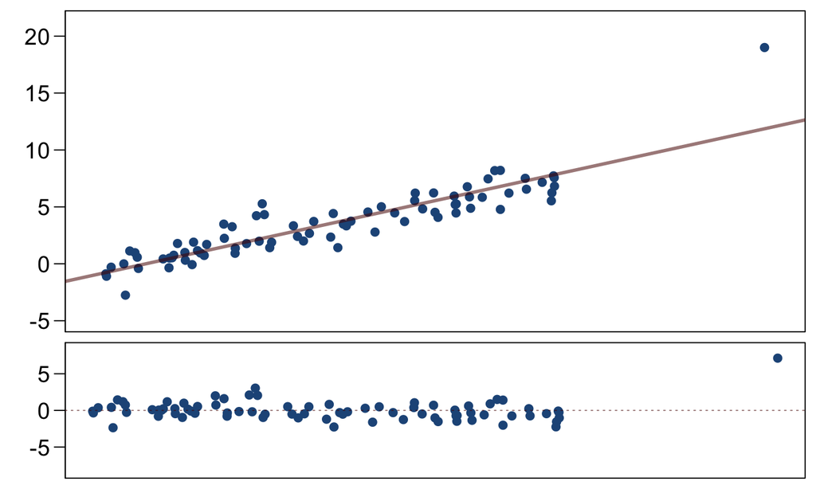

## Outlier Example Four

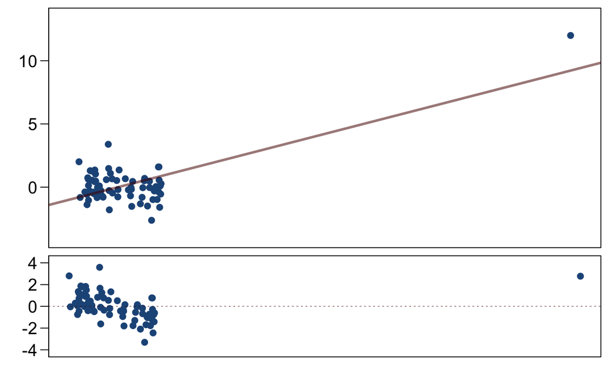

## Outlier Example Four

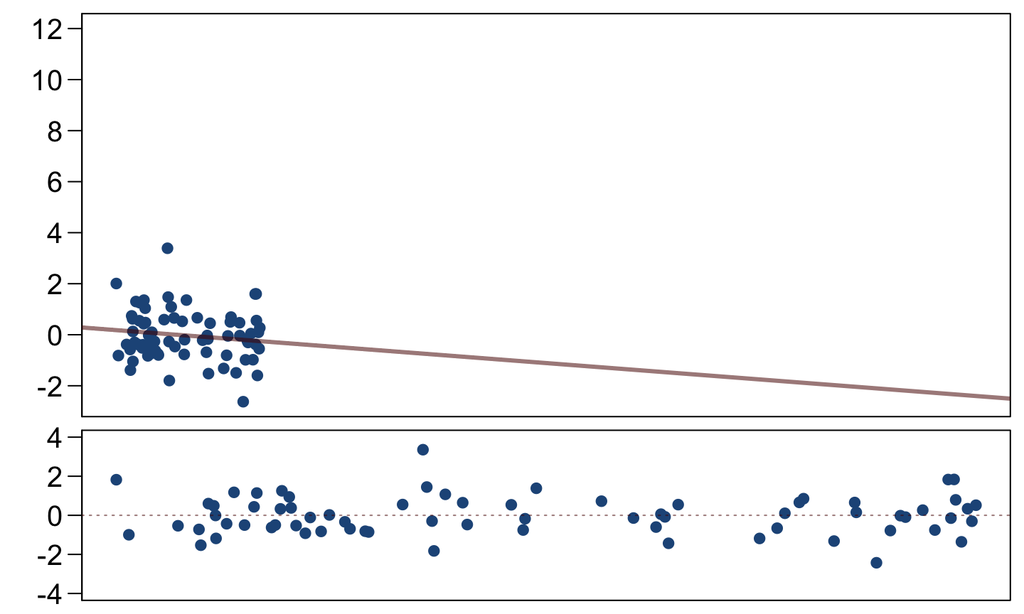

## Outliers, leverage, influence

**Outliers** are points that don't fit the trend in the rest of the data.

**High leverage points** have the potential to have an unusually large influence on the fitted model.

**Influential points** are high leverage points that cause a very different line to be fit than would be with that point removed.

## Example of high leverage, high influence

We can data on the surface temperature and light intensity of 47 stars in the star cluster CYG OB1, near Cygnus.

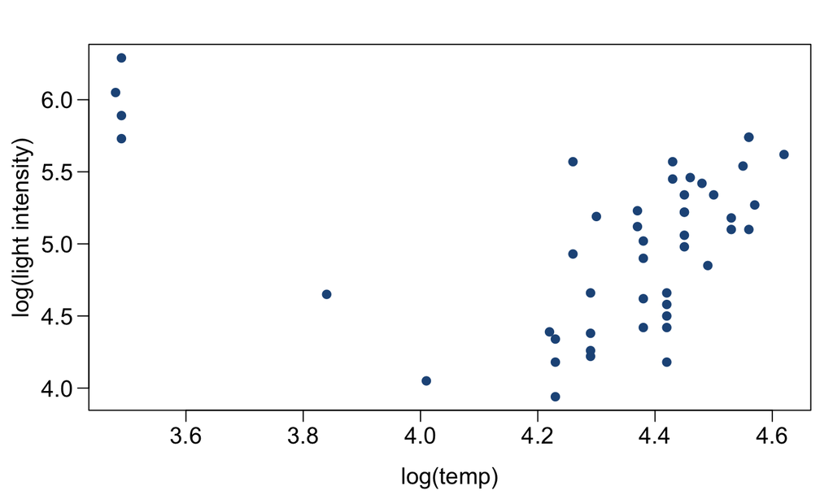

## Example of high leverage, high influence

We can data on the surface temperature and light intensity of 47 stars in the star cluster CYG OB1, near Cygnus.

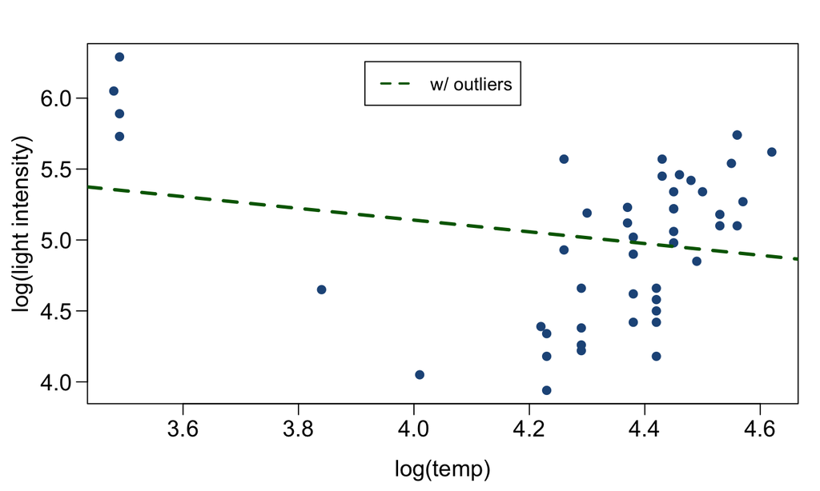

## Example of high leverage, high influence

We can data on the surface temperature and light intensity of 47 stars in the star cluster CYG OB1, near Cygnus.

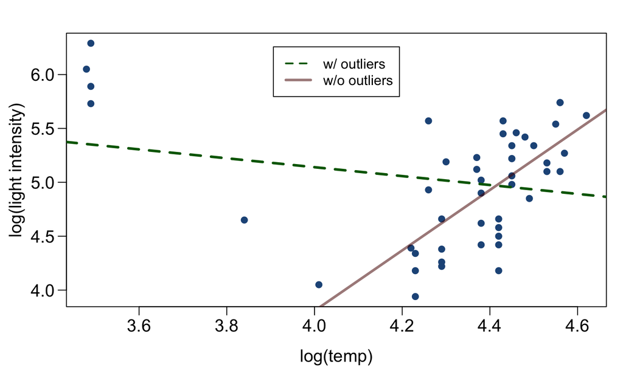

## Example of high leverage, low influence

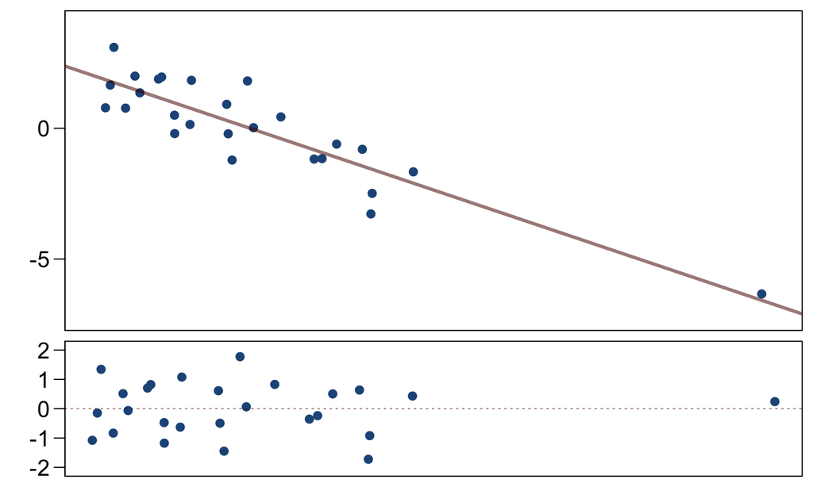

## Quantifying leverage: \(h_{ii}\)

We need a metric for the leverage of \(x_i\) that incorporates

1. The distance \(x_i\) is away from the bulk of the \(x\)'s.
2. The extent to which the fitted regression line is attracted by the given point.

\[ h_{ii} = \frac{1}{n} + \frac{(x_i - \bar{x})^2}{\sum_{j = 1}^n(x_j - \bar{x})^2} \]

## \(h_{ii}\) values

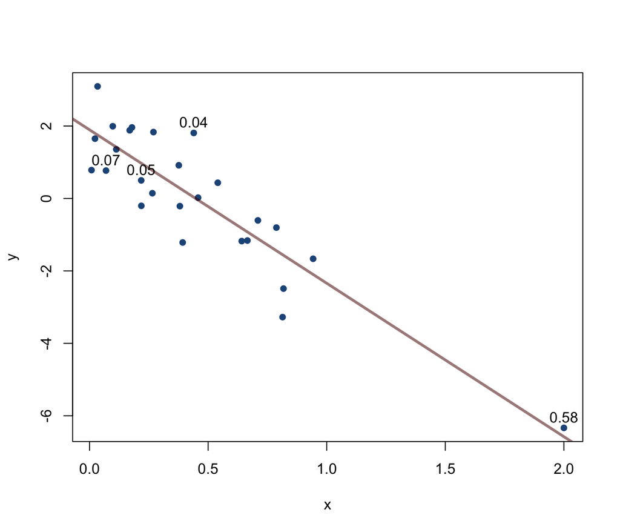

## What is "high" leverage?

**Rule of Thumb**: in simple regression, a point has "high leverage" if \(h_{ii} > 4/n\).

```r
m1 <- lm(y ~ x)
h <- lm.influence(lm(y ~ x))$hat
```

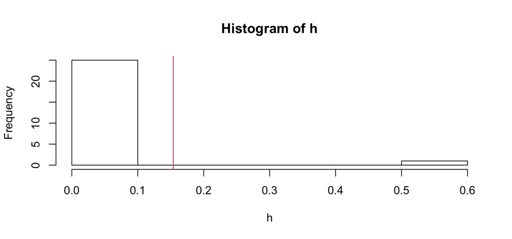

## From leverage to influence

**Leverage** measures the weight given to each point in determining the regression line.

**Influence** measures how different the regression line would be without a given point.

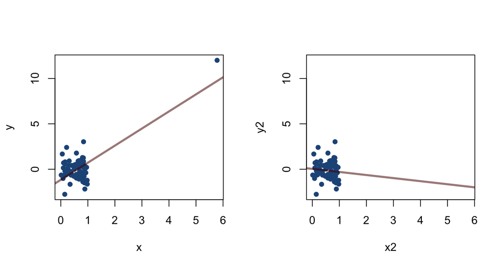

## Cook's Distance

A widely-used measure of influence:

\[ D_i = \frac{\sum_{j = 1}^n (\hat{y}_{j(i)} - \hat{y}_j)^2}{2S^2} \]

where \(\hat{y}_{j(i)}\) is the \(j^{th}\) fitted value based on the fit with the \(i^{th}\) case removed.

## Cook's Distance

An alternate form:

\[ D_i = \frac{r_i^2}{2} \frac{h_{ii}}{1 - h_{ii}} \]

To be influential a point must:

1. Have high leverage \(h_{ii}\) *and*
2. Have a high standardized residual \(r_i\)

## Cook's Distance in R

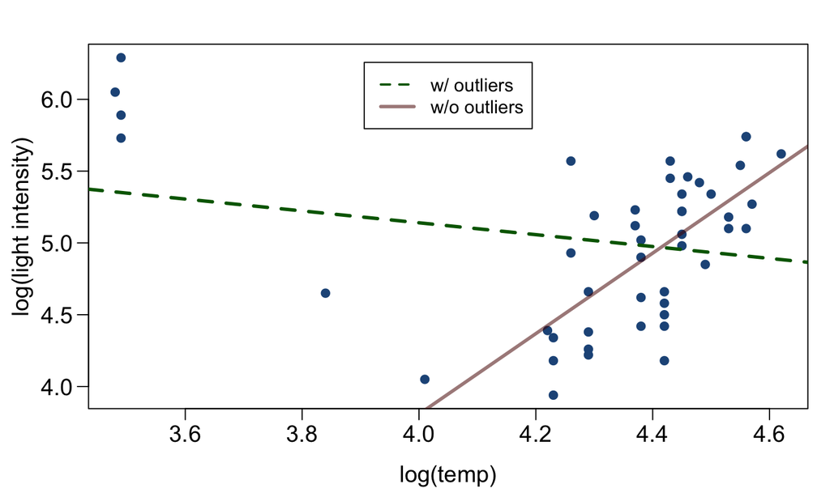

## Cook's Distance in R

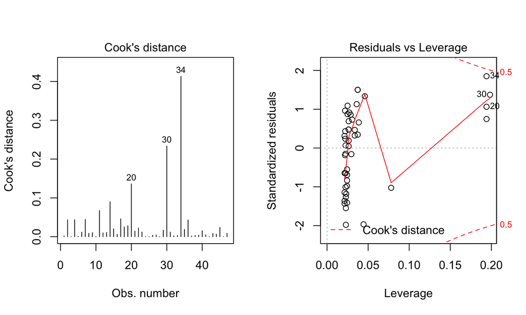

```r
m1 <- lm(light ~ temp, data = star)
par(mfrow = c(1, 2))
plot(m1, 4:5)
```